# ESM 244 (Winter 2020) Lab 1

Part 1: Data wrangling review + some new `stringr` stuff

Allison Horst

Part 1: We’ll create a new GitHub repo and R project, wrangle and visualize data from spreadsheets in R Markdown, communicate between RStudio (locally) and GitHub (remotely) to keep our updates safe

## Objectives

- Create a new repo on GitHub
- Clone the repo to create a new version-controlled R project
- Create **data** and** figures** subfolder s
- Add noaa_fisheries.csv data to **data** folder in working directory
- Create a new R Markdown document
- Attach necessary packages (`tidyverse`, `here`, `janitor`, `kableExtra`)
- Use `here::here()` for simpler (and safer) file paths
- Data tidying and wrangling (`dplyr`, `tidyr`, etc.)
- HTML tables with `kable()` and `kableExtra`
- Data visualization (`ggplot2`)

## Resources

- [Project oriented workflows](https://www.tidyverse.org/blog/2017/12/workflow-vs-script/) by Jenny Bryan
- [R4DS](https://r4ds.had.co.nz/) by Garrett Grolemund and Hadley Wickham

## Set-up

- In GitHub, create a new repository called `us-fisheries-landings`
- Clone the repo to create a version controlled project (remember, copy & paste the URL from the GitHub Clone / Download)
- In the local project working directory, create a subfolder called ‘data’
- Copy and paste the **noaa_fisheries.csv** file into the ‘data’ folder
- Create a new R Markdown document within your `us-fisheries-landings` project
- Knit your .Rmd to html, saving as `us_landings.Rmd`

**Data:** File name: noaa_fisheries.csv Description: NOAA Commercial Fisheries Landing data (1950 - 2017) Accessed from: https://www.st.nmfs.noaa.gov/commercial-fisheries/commercial-landings/ Source: Fisheries Statistics Division of the NOAA Fisheries

*Note on the data:* “aggregate” here means “These names represent aggregations of more than one species. They are not inclusive, but rather represent landings where we do not have species-specific data. Selecting”Sharks“, for example, will not return all sharks but only those where we do not have more specific information.”

## Attach packages, read in and explore the data

Attach (load) packages with `library()`:

```r
library(tidyverse)
library(here)
library(janitor)
library(kableExtra)
```

Read in the noaa_fisheries.csv data as object **us_landings**:

```r
us_landings <- read_csv(here("data","noaa_fisheries.csv"))
```

Go exploring a bit:

```r
summary(us_landings)
View(us_landings)
names(us_landings)
head(us_landings)
tail(us_landings)
```

## Some data cleaning to get salmon landings

- Clean up column names (`clean_names()`)
- Convert everything to lower case with `mutate()` + (`str_to_lower()`)
- Remove dollar signs in value column (`mutate()` + `parse_number()`)
- Remove the “aggregate” grouping indicator in species (`mutate()` + a new function! `str_remove()`) %>%
- Keep only observations that include “salmon” (`filter()`)
- Separate the grouped name (“salmon”) from any additional refined information on species (`separate()`)

We’ll break this up into two pieces:

1. A tidier version of the entire data frame
2. A subset that only contains salmon information

First: tidying the entire data frame

```r
landings_tidy <- us_landings %>%
  clean_names() %>% # Make column headers snake_case
  mutate(
    state = str_to_lower(state),
    afs_name = str_to_lower(afs_name)
  ) %>% # Converts character columns to lowercase
  mutate(dollars_num = parse_number(dollars_usd))
```

Now, getting just the salmon:

```r
salmon_landings <- landings_tidy %>%
  mutate(afs_clean = str_remove(afs_name, pattern = "aggregate")) %>%
  filter(str_detect(afs_clean, pattern = "salmon")) %>% # Detect matches for crab
  separate(afs_clean, into = c("group","species"), sep = ",")
```

Explore **salmon_landings**.

## Find grouped summary data

Find the annual total US landings and dollar value (summing across all states) for each type of salmon using `group_by()` + `summarize()`:

```r
salmon_summary <- salmon_landings %>%
  group_by(year, species) %>%
  summarize(
    tot_landings = sum(landings_pounds),
    tot_value = sum(dollars_num)
  )
```

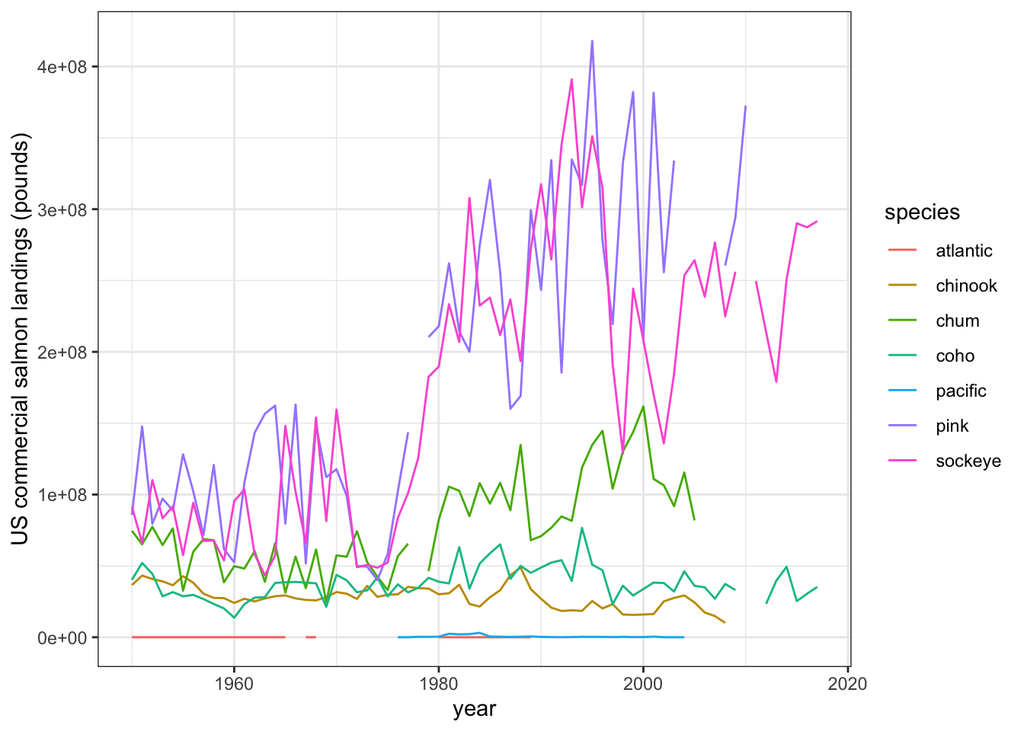

```r
salmon_landings_graph <- ggplot(salmon_summary, aes(x = year, y = tot_landings, group = species)) +
  geom_line(aes(color = species)) +
  theme_bw() +
  labs(x = "year", y = "US commercial salmon landings (pounds)")

salmon_landings_graph
```

```r
ggsave(plot = salmon_landings_graph, here("figures", "us_salmon_landings.png"),
       height = 5, width = 8)
```

## 2015 commercial fisheries value by state

Now, let’s create a finalized table of the top 5 states (by total commercial fisheries value) for 2015 .

Remember that we already created a tidied data frame, **landings_tidy**.

*Critical thinking for data wrangling workflow: Why does it make sense (especially now) that we broke our previous wrangling into two steps before getting our salmon subset?*

```r
state_value <- landings_tidy %>%
  filter(year %in% c(2015)) %>%
  group_by(state) %>%
  summarize(
    state_value = sum(dollars_num, na.rm = TRUE),
    state_landings = sum(landings_pounds, na.rm = TRUE)
  ) %>%
  arrange(-state_value) %>%
  head(5)
```

Look at our summary data frame, **state_value** - which contains all the information we want, but doesn’t look very finalized.

What are some ways we’d want to finalize it for a report?

- Change units (to millions of dollars and pounds)
- Update column names
- Capitalize the state names

Let’s do it!

## Making a nice HTML table

First, we’ll create it as a finalized data frame:

```r
state_table <- state_value %>%
  mutate(`Fisheries value ($ millions)` = round(state_value / 1e6, 2),
         `Landings (million pounds)` = round(state_landings / 1e6, 1)) %>%
  select(-state_value, -state_landings) %>%
  rename(State = state) %>%
  mutate(State = str_to_title(State))
```

Now, use `kable()` + `kableExtra` to nicely format it for HTML:

```r
kable(state_table) %>%
  kable_styling(bootstrap_options = "striped",
                full_width = FALSE) %>%
  add_header_above(c("", "2015 US commercial fisheries - top 5 states by value" = 2))
```

| State | 2015 US commercial fisheries - top 5 states by value Fisheries value ($ millions) | 2015 US commercial fisheries - top 5 states by value Landings (million pounds) |
| --- | --- | --- |
| Alaska | 1750.20 | 6015.1 |
| Maine | 628.95 | 252.5 |
| Massachusetts | 523.67 | 259.8 |
| Louisiana | 369.62 | 1068.5 |
| Washington | 221.54 | 148.8 |

## Sync with GitHub remote

Stage, commit, (pull), and push your updates to GitHub for safe storage & sharing. Check to make sure that the changes have been stored.

## End Part 1!